# Packet classification for mobile applications

# Var_block = variance combining all the variance of the flow in a block

```python
limit = 4.5

for index, row in app.iterrows():
    if(index==0):
        begin = 0
        sum_length = row['flow_length']
        flow_min =  row['flow_start']
        flow_max = row['flow_start']
        mean_block = row['mean']
        var_bloc = row['variance']
    else:
        current = float(row['flow_start'])
        previous = float(app['flow_start'][index-1])

    if((index>0 and current>(previous+limit)) or (index==app.shape[0]-1)):

        if(current>previous+limit):
            end = index
        if(index==app.shape[0]-1): #last element
            if(current<previous+limit):
                end = index+1
            #proper classification for last flow of dataframe
            else:
                app.at[index,'Num_flow'] = 1
                app.at[index,'Duration'] = 0
                app.at[index,'Avg_flow_length'] = app['flow_length'][index]
                app.at[index,'Mean_block'] = mean_block
                app.at[index,'Var_block'] = var_bloc
                app.at[index,'Position'] = 0
                app.at[index,'Shift_from_start'] = 0
        #print("index ",index," end ",end," begin ", begin)
        if(end-begin == 1):
            app.at[begin,'Num_flow'] = 1
            app.at[begin,'Duration'] = 0
            app.at[begin,'Avg_flow_length'] = app['flow_length'][begin]
            app.at[begin,'Mean_block'] = mean_block
            app.at[begin,'Var_block'] = var_bloc
            app.at[begin,'Position'] = 0
            app.at[begin,'Shift_from_start'] = 0
            begin = index
            continue

        duration = flow_max - flow_min
        number = end-begin
        avg = sum_length/number
        counter = 0
        first_flow = app['flow_start'][begin]
        for j in range(begin,end):
            app.at[j,'Num_flow'] = number
            app.at[j,'Duration'] = duration
            app.at[j,'Avg_flow_length'] = avg
            app.at[j,'Mean_block'] = float(mean_block/number)
            app.at[j,'Var_block'] = float(var_bloc/number)
            app.at[j,'Position']=counter
            app.at[j,'Shift_from_start'] = app['flow_start'][j] - first_flow
            counter+=1

        begin = index
        sum_length = row['flow_length']
        flow_min =  float(row['flow_start'])
        flow_max = float(row['flow_start'])
        mean_block = float(row['mean'])
        var_bloc = float(row['variance'])
    else:
        if(float(row['flow_start'])>flow_max):
            flow_max = float(row['flow_start'])
        elif(float(row['flow_start'])<flow_min):
            flow_min = float(row['flow_start'])
        sum_length+= row['flow_length']
        mean_block += float(row['mean'])
        var_bloc += float(row['variance'])

print("Current dataset at this stage:")
app
```

```
Current dataset at this stage:
```

|  | app | action | sequence | action_start | flow_number | IP_destination | IP_dest_resolved | port_source | port_destination | flow_length | ... | packets_length_total | Num_flow | Duration | Avg_flow_length | Mean_block | Var_block | Position | Shift_from_start | mean | variance |
| --- | --- | --- | --- | --- | --- | --- | --- | --- | --- | --- | --- | --- | --- | --- | --- | --- | --- | --- | --- | --- | --- |
| 0 | twitter | open Twitter | sequence_1 | 1.383151e+09 | 50319 | 10.22.6.254 | NaN | 51190.0 | 53.0 | 2 | ... | [75, -273] | 12 | 5.389641 | 6.750000 | 435.688575 | 307.327827 | 0 | 0.000000 | 140.340000 | 93.102118 |
| 1 | twitter | open Twitter | sequence_1 | 1.383151e+09 | 50320 | 10.22.6.254 | NaN | 52518.0 | 53.0 | 2 | ... | [84, -546] | 12 | 5.389641 | 6.750000 | 435.688575 | 307.327827 | 1 | -0.133374 | 236.460000 | 217.238276 |
| 2 | twitter | open Twitter | sequence_1 | 1.383151e+09 | 50321 | 10.22.6.254 | NaN | 17437.0 | 53.0 | 2 | ... | [75, -273] | 12 | 5.389641 | 6.750000 | 435.688575 | 307.327827 | 2 | -0.001584 | 140.340000 | 93.102118 |
| 3 | twitter | open Twitter | sequence_1 | 1.383151e+09 | 50322 | 10.22.6.254 | NaN | 27669.0 | 53.0 | 2 | ... | [78, -260] | 12 | 5.389641 | 6.750000 | 435.688575 | 307.327827 | 3 | 0.260676 | 138.060000 | 85.578715 |
| 4 | twitter | open Twitter | sequence_1 | 1.383151e+09 | 50323 | 10.22.6.254 | NaN | 25817.0 | 53.0 | 2 | ... | [86, -422] | 12 | 5.389641 | 6.750000 | 435.688575 | 307.327827 | 4 | 2.959367 | 196.880000 | 157.991473 |
| 5 | twitter | open Twitter | sequence_1 | 1.383151e+09 | 50324 | 199.16.156.43 | 199.16.156.43 | 56459.0 | 443.0 | 12 | ... | [250, -1514, -1514, -574, 188, -113, 828, -742... | 12 | 5.389641 | 6.750000 | 435.688575 | 307.327827 | 5 | 0.846959 | 684.389098 | 452.635558 |
| 6 | twitter | open Twitter | sequence_1 | 1.383151e+09 | 50325 | 199.16.156.72 | 199.16.156.72 | 57881.0 | 443.0 | 14 | ... | [250, -1514, -1514, -536, 188, -113, 842, -847... | 12 | 5.389641 | 6.750000 | 435.688575 | 307.327827 | 6 | 3.189010 | 726.360759 | 417.243895 |
| 7 | twitter | open Twitter | sequence_1 | 1.383151e+09 | 50326 | 199.16.156.107 | 199.16.156.107 | 48846.0 | 443.0 | 9 | ... | [282, -1514, -1514, -574, 188, -113, 824, -742... | 12 | 5.389641 | 6.750000 | 435.688575 | 307.327827 | 7 | 5.256267 | 704.017544 | 509.232094 |
| 8 | twitter | open Twitter | sequence_1 | 1.383151e+09 | 50327 | 10.22.6.254 | NaN | 52725.0 | 53.0 | 2 | ... | [78, -260] | 12 | 5.389641 | 6.750000 | 435.688575 | 307.327827 | 8 | 5.121539 | 138.060000 | 85.578715 |
| 9 | twitter | open Twitter | sequence_1 | 1.383151e+09 | 50328 | 173.194.113.229 | mil01s18-in-f5.1e100.net | 48399.0 | 443.0 | 10 | ... | [282, -1484, -1484, -1326, -187, 188, -113, 55... | 12 | 5.389641 | 6.750000 | 435.688575 | 307.327827 | 9 | 3.059991 | 527.143777 | 497.779489 |
| 10 | twitter | open Twitter | sequence_1 | 1.383151e+09 | 50329 | 54.225.187.16 | ec2-54-225-187-16.compute-1.amazonaws.com | 56284.0 | 443.0 | 8 | ... | [287, -1514, -1514, -435, 376, -300, 823, -1264] | 12 | 5.389641 | 6.750000 | 435.688575 | 307.327827 | 10 | 3.166884 | 725.281421 | 470.632518 |
| 11 | twitter | open Twitter | sequence_1 | 1.383151e+09 | 50330 | 199.16.156.199 | 199.16.156.199 | 50798.0 | 443.0 | 14 | ... | [250, -1514, -1514, -536, 188, -113, 979, -869... | 12 | 5.389641 | 6.750000 | 435.688575 | 307.327827 | 11 | 3.189223 | 730.590301 | 514.716837 |
| 12 | twitter | open Twitter | sequence_1 | 1.383151e+09 | 50331 | 199.16.156.43 | 199.16.156.43 | 56459.0 | 443.0 | 1 | ... | [-93] | 4 | 4.027171 | 1.000000 | 93.000000 | 0.000000 | 0 | 0.000000 | 93.000000 | 0.000000 |
| 13 | twitter | open Twitter | sequence_1 | 1.383151e+09 | 50332 | 199.16.156.72 | 199.16.156.72 | 57881.0 | 443.0 | 1 | ... | [-93] | 4 | 4.027171 | 1.000000 | 93.000000 | 0.000000 | 1 | 2.527410 | 93.000000 | 0.000000 |
| 14 | twitter | open Twitter | sequence_1 | 1.383151e+09 | 50333 | 199.16.156.107 | 199.16.156.107 | 48846.0 | 443.0 | 1 | ... | [-93] | 4 | 4.027171 | 1.000000 | 93.000000 | 0.000000 | 2 | 4.027171 | 93.000000 | 0.000000 |
| 15 | twitter | open Twitter | sequence_1 | 1.383151e+09 | 50334 | 199.16.156.199 | 199.16.156.199 | 50798.0 | 443.0 | 1 | ... | [-93] | 4 | 4.027171 | 1.000000 | 93.000000 | 0.000000 | 3 | 2.096138 | 93.000000 | 0.000000 |
| 16 | twitter | open Twitter | sequence_1 | 1.383151e+09 | 50335 | 10.22.6.254 | NaN | 64915.0 | 53.0 | 2 | ... | [71, -269] | 8 | 0.559473 | 7.250000 | 384.332347 | 226.966777 | 0 | 0.000000 | 136.340000 | 93.102118 |
| 17 | twitter | open Twitter | sequence_1 | 1.383151e+09 | 50336 | 10.22.6.254 | NaN | 18721.0 | 53.0 | 2 | ... | [75, -273] | 8 | 0.559473 | 7.250000 | 384.332347 | 226.966777 | 1 | -0.372628 | 140.340000 | 93.102118 |
| 18 | twitter | open Twitter | sequence_1 | 1.383151e+09 | 50337 | 199.16.156.72 | 199.16.156.72 | 57881.0 | 443.0 | 1 | ... | [93] | 8 | 0.559473 | 7.250000 | 384.332347 | 226.966777 | 2 | -0.372946 | 93.000000 | 0.000000 |
| 19 | twitter | open Twitter | sequence_1 | 1.383151e+09 | 50338 | 199.16.156.8 | 199.16.156.8 | 37912.0 | 443.0 | 9 | ... | [250, -1514, -1514, -536, 188, -113, 801, -867... | 8 | 0.559473 | 7.250000 | 384.332347 | 226.966777 | 3 | -0.188854 | 593.714286 | 488.865449 |
| 20 | twitter | open Twitter | sequence_1 | 1.383151e+09 | 50339 | 199.16.156.8 | 199.16.156.8 | 56427.0 | 443.0 | 32 | ... | [250, -1514, -1514, -536, 188, -113, 861, -839... | 8 | 0.559473 | 7.250000 | 384.332347 | 226.966777 | 4 | -0.193305 | 1125.857513 | 540.587360 |
| 21 | twitter | open Twitter | sequence_1 | 1.383151e+09 | 50340 | 10.22.6.254 | NaN | 50116.0 | 53.0 | 2 | ... | [75, -273] | 8 | 0.559473 | 7.250000 | 384.332347 | 226.966777 | 5 | -0.372081 | 140.340000 | 93.102118 |
| 22 | twitter | open Twitter | sequence_1 | 1.383151e+09 | 50341 | 199.16.156.199 | 199.16.156.199 | 50798.0 | 443.0 | 1 | ... | [93] | 8 | 0.559473 | 7.250000 | 384.332347 | 226.966777 | 6 | -0.372130 | 93.000000 | 0.000000 |
| 23 | twitter | open Twitter | sequence_1 | 1.383151e+09 | 50342 | 199.16.156.70 | 199.16.156.70 | 55312.0 | 443.0 | 9 | ... | [250, -1514, -1514, -803, 188, -113, 876, 1294... | 8 | 0.559473 | 7.250000 | 384.332347 | 226.966777 | 7 | 0.186527 | 752.066975 | 506.975055 |
| 24 | twitter | open Twitter | sequence_1 | 1.383151e+09 | 50343 | 54.225.187.16 | ec2-54-225-187-16.compute-1.amazonaws.com | 56284.0 | 443.0 | 1 | ... | [-89] | 1 | 0.000000 | 1.000000 | 89.000000 | 0.000000 | 0 | 0.000000 | 89.000000 | 0.000000 |
| 25 | twitter | open Twitter | sequence_1 | 1.383151e+09 | 50344 | 199.16.156.70 | 199.16.156.70 | 55312.0 | 443.0 | 1 | ... | [-93] | 3 | 25.187670 | 1.000000 | 91.666667 | 0.000000 | 0 | 0.000000 | 93.000000 | 0.000000 |
| 26 | twitter | open Twitter | sequence_1 | 1.383151e+09 | 50345 | 199.16.156.8 | 199.16.156.8 | 37912.0 | 443.0 | 1 | ... | [-93] | 3 | 25.187670 | 1.000000 | 91.666667 | 0.000000 | 1 | -0.373413 | 93.000000 | 0.000000 |
| 27 | twitter | open Twitter | sequence_1 | 1.383151e+09 | 50346 | 199.16.156.8 | 199.16.156.8 | 56427.0 | 443.0 | 1 | ... | [-93] | 3 | 25.187670 | 1.000000 | 91.666667 | 0.000000 | 2 | -0.387031 | 93.000000 | 0.000000 |
| 28 | twitter | contact selection | sequence_1 | 1.383151e+09 | 50347 | 199.16.156.8 | 199.16.156.8 | 56427.0 | 443.0 | 1 | ... | [93] | 4 | 0.180141 | 3.250000 | 252.730363 | 145.286158 | 0 | 0.000000 | 93.000000 | 0.000000 |
| 29 | twitter | contact selection | sequence_1 | 1.383151e+09 | 50348 | 199.16.156.231 | 199.16.156.231 | 34902.0 | 443.0 | 9 | ... | [250, -1514, -1514, -536, 188, -113, 1021, -87... | 4 | 0.180141 | 3.250000 | 252.730363 | 145.286158 | 1 | 0.180141 | 684.581454 | 488.042515 |
| ... | ... | ... | ... | ... | ... | ... | ... | ... | ... | ... | ... | ... | ... | ... | ... | ... | ... | ... | ... | ... | ... |
| 36229 | twitter | edit selection | sequence_20 | 1.392325e+09 | 86548 | 199.16.156.230 | 199.16.156.230 | 38276.0 | 443.0 | 8 | ... | [282, -1514, -1514, -803, 188, -113, 1069, -747] | 3 | 12.429356 | 1.666667 | 114.650000 | 49.372335 | 0 | 0.000000 | 704.688525 | 506.541915 |
| 36230 | twitter | edit selection | sequence_20 | 1.392325e+09 | 86549 | 10.22.6.254 | NaN | 27382.0 | 53.0 | 2 | ... | [71, -205] | 3 | 12.429356 | 1.666667 | 114.650000 | 49.372335 | 1 | -0.180406 | 115.220000 | 63.008504 |
| 36231 | twitter | edit selection | sequence_20 | 1.392325e+09 | 86550 | 199.16.156.6 | 199.16.156.6 | 56922.0 | 443.0 | 1 | ... | [93] | 3 | 12.429356 | 1.666667 | 114.650000 | 49.372335 | 2 | -0.180789 | 93.000000 | 0.000000 |
| 36232 | twitter | Other | sequence_20 | 1.392325e+09 | 86551 | 199.16.156.230 | 199.16.156.230 | 38276.0 | 443.0 | 1 | ... | [-93] | 1 | 0.000000 | 1.000000 | 93.000000 | 0.000000 | 0 | 0.000000 | 93.000000 | 0.000000 |
| 36233 | twitter | send selection | sequence_20 | 1.392325e+09 | 86552 | 10.22.6.254 | NaN | 1193.0 | 53.0 | 2 | ... | [75, -209] | 4 | 56.275347 | 3.000000 | 238.310150 | 121.475107 | 0 | 0.000000 | 119.220000 | 63.008504 |
| 36234 | twitter | send selection | sequence_20 | 1.392325e+09 | 86553 | 199.16.156.231 | 199.16.156.231 | 37209.0 | 443.0 | 1 | ... | [93] | 4 | 56.275347 | 3.000000 | 238.310150 | 121.475107 | 1 | -0.000752 | 93.000000 | 0.000000 |
| 36235 | twitter | send selection | sequence_20 | 1.392325e+09 | 86554 | 199.16.156.72 | 199.16.156.72 | 33833.0 | 443.0 | 1 | ... | [93] | 4 | 56.275347 | 3.000000 | 238.310150 | 121.475107 | 2 | -0.000027 | 93.000000 | 0.000000 |
| 36236 | twitter | send selection | sequence_20 | 1.392325e+09 | 86555 | 199.16.156.104 | 199.16.156.104 | 56899.0 | 443.0 | 9 | ... | [250, -1514, -1514, -472, 188, -113, 987, -817... | 4 | 56.275347 | 3.000000 | 238.310150 | 121.475107 | 3 | 0.177130 | 674.240602 | 485.900427 |
| 36237 | twitter | back to me | sequence_20 | 1.392325e+09 | 86556 | 199.16.156.104 | 199.16.156.104 | 56899.0 | 443.0 | 1 | ... | [-93] | 1 | 0.000000 | 1.000000 | 93.000000 | 0.000000 | 0 | 0.000000 | 93.000000 | 0.000000 |
| 36238 | twitter | new tweet selection | sequence_20 | 1.392325e+09 | 86557 | 199.16.156.230 | 199.16.156.230 | 38276.0 | 443.0 | 1 | ... | [93] | 3 | 29.649355 | 4.000000 | 280.954011 | 173.203491 | 0 | 0.000000 | 93.000000 | 0.000000 |
| 36239 | twitter | new tweet selection | sequence_20 | 1.392325e+09 | 86558 | 199.16.156.230 | 199.16.156.230 | 48464.0 | 443.0 | 9 | ... | [282, -1514, -1514, -803, 188, -113, 891, 430,... | 3 | 29.649355 | 4.000000 | 280.954011 | 173.203491 | 1 | 0.173223 | 634.642032 | 456.601968 |
| 36240 | twitter | new tweet selection | sequence_20 | 1.392325e+09 | 86559 | 10.22.6.254 | NaN | 58942.0 | 53.0 | 2 | ... | [71, -205] | 3 | 29.649355 | 4.000000 | 280.954011 | 173.203491 | 2 | 0.000034 | 115.220000 | 63.008504 |
| 36241 | twitter | writing tweet | sequence_20 | 1.392325e+09 | 86560 | 199.16.156.230 | 199.16.156.230 | 48464.0 | 443.0 | 1 | ... | [-93] | 1 | 0.000000 | 1.000000 | 93.000000 | 0.000000 | 0 | 0.000000 | 93.000000 | 0.000000 |
| 36242 | twitter | writing tweet | sequence_20 | 1.392325e+09 | 86561 | 199.16.156.230 | 199.16.156.230 | 48464.0 | 443.0 | 1 | ... | [93] | 3 | 31.563147 | 3.666667 | 304.485902 | 189.982190 | 0 | 0.000000 | 93.000000 | 0.000000 |
| 36243 | twitter | writing tweet | sequence_20 | 1.392325e+09 | 86562 | 199.16.156.102 | 199.16.156.102 | 51443.0 | 443.0 | 8 | ... | [282, -1514, -1514, -803, 188, -113, 1072, -747] | 3 | 31.563147 | 3.666667 | 304.485902 | 189.982190 | 1 | 0.181538 | 705.237705 | 506.938066 |
| 36244 | twitter | writing tweet | sequence_20 | 1.392325e+09 | 86563 | 10.22.6.254 | NaN | 35259.0 | 53.0 | 2 | ... | [71, -205] | 3 | 31.563147 | 3.666667 | 304.485902 | 189.982190 | 2 | 0.000299 | 115.220000 | 63.008504 |
| 36245 | twitter | send tweet selection | sequence_20 | 1.392325e+09 | 86564 | 199.16.156.104 | 199.16.156.104 | 56899.0 | 443.0 | 1 | ... | [93] | 4 | 5.732903 | 3.250000 | 245.778684 | 137.619372 | 0 | 0.000000 | 93.000000 | 0.000000 |
| 36246 | twitter | send tweet selection | sequence_20 | 1.392325e+09 | 86565 | 10.22.6.254 | NaN | 63329.0 | 53.0 | 2 | ... | [75, -209] | 4 | 5.732903 | 3.250000 | 245.778684 | 137.619372 | 1 | 0.000714 | 119.220000 | 63.008504 |
| 36247 | twitter | send tweet selection | sequence_20 | 1.392325e+09 | 86566 | 199.16.156.104 | 199.16.156.104 | 46660.0 | 443.0 | 9 | ... | [250, -1514, -1514, -472, 188, -113, 993, -817... | 4 | 5.732903 | 3.250000 | 245.778684 | 137.619372 | 2 | 1.367353 | 677.894737 | 487.468983 |
| 36248 | twitter | send tweet selection | sequence_20 | 1.392325e+09 | 86567 | 199.16.156.102 | 199.16.156.102 | 51443.0 | 443.0 | 1 | ... | [-93] | 4 | 5.732903 | 3.250000 | 245.778684 | 137.619372 | 3 | 5.732903 | 93.000000 | 0.000000 |
| 36249 | twitter | back to home | sequence_20 | 1.392325e+09 | 86568 | 199.16.156.104 | 199.16.156.104 | 46660.0 | 443.0 | 1 | ... | [-93] | 1 | 0.000000 | 1.000000 | 93.000000 | 0.000000 | 0 | 0.000000 | 93.000000 | 0.000000 |
| 36250 | twitter | Twitter in backgroud | sequence_20 | 1.392325e+09 | 86569 | 10.22.6.254 | NaN | 35140.0 | 53.0 | 2 | ... | [71, -205] | 4 | 29.894217 | 3.250000 | 251.819913 | 133.584377 | 0 | 0.000000 | 115.220000 | 63.008504 |
| 36251 | twitter | Twitter in backgroud | sequence_20 | 1.392325e+09 | 86570 | 199.16.156.102 | 199.16.156.102 | 51443.0 | 443.0 | 1 | ... | [93] | 4 | 29.894217 | 3.250000 | 251.819913 | 133.584377 | 1 | -0.001413 | 93.000000 | 0.000000 |
| 36252 | twitter | Twitter in backgroud | sequence_20 | 1.392325e+09 | 86571 | 10.22.6.254 | NaN | 40249.0 | 53.0 | 2 | ... | [76, -257] | 4 | 29.894217 | 3.250000 | 251.819913 | 133.584377 | 2 | 1.365806 | 135.730000 | 85.108502 |
| 36253 | twitter | Twitter in backgroud | sequence_20 | 1.392325e+09 | 86572 | 199.16.156.230 | 199.16.156.230 | 45165.0 | 443.0 | 9 | ... | [282, -1514, -1514, -803, 188, -113, 891, 759,... | 4 | 29.894217 | 3.250000 | 251.819913 | 133.584377 | 3 | 0.182504 | 685.549654 | 449.229006 |
| 36254 | twitter | Twitter in backgroud | sequence_20 | 1.392325e+09 | 86573 | 199.16.156.230 | 199.16.156.230 | 45165.0 | 443.0 | 1 | ... | [-93] | 1 | 0.000000 | 1.000000 | 93.000000 | 0.000000 | 0 | 0.000000 | 93.000000 | 0.000000 |
| 36255 | twitter | Twitter in backgroud | sequence_20 | 1.392325e+09 | 86574 | 10.22.6.254 | NaN | 59423.0 | 53.0 | 2 | ... | [71, -205] | 3 | 31.421546 | 3.666667 | 272.103156 | 152.883815 | 0 | 0.000000 | 115.220000 | 63.008504 |
| 36256 | twitter | Twitter in backgroud | sequence_20 | 1.392325e+09 | 86575 | 199.16.156.230 | 199.16.156.230 | 42914.0 | 443.0 | 9 | ... | [282, -1514, -1514, -803, 188, -113, 891, 402,... | 3 | 31.421546 | 3.666667 | 272.103156 | 152.883815 | 1 | 0.178931 | 630.309469 | 458.651444 |
| 36257 | twitter | Twitter in backgroud | sequence_20 | 1.392325e+09 | 86576 | 199.16.156.230 | 199.16.156.230 | 45165.0 | 443.0 | 1 | ... | [93] | 3 | 31.421546 | 3.666667 | 272.103156 | 152.883815 | 2 | -0.000455 | 93.000000 | 0.000000 |
| 36258 | twitter | Twitter in backgroud | sequence_20 | 1.392325e+09 | 86577 | 199.16.156.230 | 199.16.156.230 | 42914.0 | 443.0 | 1 | ... | [-93] | 1 | 0.000000 | 1.000000 | 816.309469 | 458.651444 | 0 | 0.000000 | 93.000000 | 0.000000 |

36259 rows × 21 columns

Each action for each flow is stored in a label. For the training we need to compute the one hot encoding of that value. It means that we need to define the number of columns equals to the different value. For each row, the features will be all equals to 0 excepts for the columns related to that label.

```python
#Contains the label related to each sample
y = pd.DataFrame(app['action'])
#One hot encoding for the label
one_hot = pd.get_dummies(y["action"])
#Store the value of all the label
values = one_hot.columns.values

print("Value related to all different action is stored in the following array")
print(values)
```

```
Value related to all different action is stored in the following array
['Other' 'Twitter in backgroud' 'back to home' 'back to me'
 'contact selection' 'direct messages selection' 'discover selection'
 'edit selection' 'first message selection' 'followers selection'
 'following selection' 'me selection' 'new tweet selection' 'open Twitter'
 'refresh home' 'send selection' 'send tweet selection' 'tweets selection'
 'writing tweet']
```

Last step is the deletion of the useless features.

```python
#Delete the useless columns in the dataframe
selected_features = app.drop(columns = ['app','action','sequence','action_start','flow_number','IP_destination','IP_dest_resolved','port_source','port_destination','packets_length_total','flow_start'])
#Final dataframe with all the features
print("All the feature used for the trainig and test will be:")
selected_features
```

```
All the feature used for the trainig and test will be:
```

|  | flow_length | Num_flow | Duration | Avg_flow_length | Mean_block | Var_block | Position | Shift_from_start | mean | variance |
| --- | --- | --- | --- | --- | --- | --- | --- | --- | --- | --- |
| 0 | 2 | 12 | 5.389641 | 6.750000 | 435.688575 | 307.327827 | 0 | 0.000000 | 140.340000 | 93.102118 |
| 1 | 2 | 12 | 5.389641 | 6.750000 | 435.688575 | 307.327827 | 1 | -0.133374 | 236.460000 | 217.238276 |
| 2 | 2 | 12 | 5.389641 | 6.750000 | 435.688575 | 307.327827 | 2 | -0.001584 | 140.340000 | 93.102118 |
| 3 | 2 | 12 | 5.389641 | 6.750000 | 435.688575 | 307.327827 | 3 | 0.260676 | 138.060000 | 85.578715 |
| 4 | 2 | 12 | 5.389641 | 6.750000 | 435.688575 | 307.327827 | 4 | 2.959367 | 196.880000 | 157.991473 |
| 5 | 12 | 12 | 5.389641 | 6.750000 | 435.688575 | 307.327827 | 5 | 0.846959 | 684.389098 | 452.635558 |
| 6 | 14 | 12 | 5.389641 | 6.750000 | 435.688575 | 307.327827 | 6 | 3.189010 | 726.360759 | 417.243895 |
| 7 | 9 | 12 | 5.389641 | 6.750000 | 435.688575 | 307.327827 | 7 | 5.256267 | 704.017544 | 509.232094 |
| 8 | 2 | 12 | 5.389641 | 6.750000 | 435.688575 | 307.327827 | 8 | 5.121539 | 138.060000 | 85.578715 |
| 9 | 10 | 12 | 5.389641 | 6.750000 | 435.688575 | 307.327827 | 9 | 3.059991 | 527.143777 | 497.779489 |
| 10 | 8 | 12 | 5.389641 | 6.750000 | 435.688575 | 307.327827 | 10 | 3.166884 | 725.281421 | 470.632518 |
| 11 | 14 | 12 | 5.389641 | 6.750000 | 435.688575 | 307.327827 | 11 | 3.189223 | 730.590301 | 514.716837 |
| 12 | 1 | 4 | 4.027171 | 1.000000 | 93.000000 | 0.000000 | 0 | 0.000000 | 93.000000 | 0.000000 |
| 13 | 1 | 4 | 4.027171 | 1.000000 | 93.000000 | 0.000000 | 1 | 2.527410 | 93.000000 | 0.000000 |
| 14 | 1 | 4 | 4.027171 | 1.000000 | 93.000000 | 0.000000 | 2 | 4.027171 | 93.000000 | 0.000000 |
| 15 | 1 | 4 | 4.027171 | 1.000000 | 93.000000 | 0.000000 | 3 | 2.096138 | 93.000000 | 0.000000 |
| 16 | 2 | 8 | 0.559473 | 7.250000 | 384.332347 | 226.966777 | 0 | 0.000000 | 136.340000 | 93.102118 |
| 17 | 2 | 8 | 0.559473 | 7.250000 | 384.332347 | 226.966777 | 1 | -0.372628 | 140.340000 | 93.102118 |
| 18 | 1 | 8 | 0.559473 | 7.250000 | 384.332347 | 226.966777 | 2 | -0.372946 | 93.000000 | 0.000000 |
| 19 | 9 | 8 | 0.559473 | 7.250000 | 384.332347 | 226.966777 | 3 | -0.188854 | 593.714286 | 488.865449 |
| 20 | 32 | 8 | 0.559473 | 7.250000 | 384.332347 | 226.966777 | 4 | -0.193305 | 1125.857513 | 540.587360 |
| 21 | 2 | 8 | 0.559473 | 7.250000 | 384.332347 | 226.966777 | 5 | -0.372081 | 140.340000 | 93.102118 |
| 22 | 1 | 8 | 0.559473 | 7.250000 | 384.332347 | 226.966777 | 6 | -0.372130 | 93.000000 | 0.000000 |
| 23 | 9 | 8 | 0.559473 | 7.250000 | 384.332347 | 226.966777 | 7 | 0.186527 | 752.066975 | 506.975055 |
| 24 | 1 | 1 | 0.000000 | 1.000000 | 89.000000 | 0.000000 | 0 | 0.000000 | 89.000000 | 0.000000 |
| 25 | 1 | 3 | 25.187670 | 1.000000 | 91.666667 | 0.000000 | 0 | 0.000000 | 93.000000 | 0.000000 |
| 26 | 1 | 3 | 25.187670 | 1.000000 | 91.666667 | 0.000000 | 1 | -0.373413 | 93.000000 | 0.000000 |
| 27 | 1 | 3 | 25.187670 | 1.000000 | 91.666667 | 0.000000 | 2 | -0.387031 | 93.000000 | 0.000000 |
| 28 | 1 | 4 | 0.180141 | 3.250000 | 252.730363 | 145.286158 | 0 | 0.000000 | 93.000000 | 0.000000 |
| 29 | 9 | 4 | 0.180141 | 3.250000 | 252.730363 | 145.286158 | 1 | 0.180141 | 684.581454 | 488.042515 |
| ... | ... | ... | ... | ... | ... | ... | ... | ... | ... | ... |
| 36229 | 8 | 3 | 12.429356 | 1.666667 | 114.650000 | 49.372335 | 0 | 0.000000 | 704.688525 | 506.541915 |
| 36230 | 2 | 3 | 12.429356 | 1.666667 | 114.650000 | 49.372335 | 1 | -0.180406 | 115.220000 | 63.008504 |
| 36231 | 1 | 3 | 12.429356 | 1.666667 | 114.650000 | 49.372335 | 2 | -0.180789 | 93.000000 | 0.000000 |
| 36232 | 1 | 1 | 0.000000 | 1.000000 | 93.000000 | 0.000000 | 0 | 0.000000 | 93.000000 | 0.000000 |
| 36233 | 2 | 4 | 56.275347 | 3.000000 | 238.310150 | 121.475107 | 0 | 0.000000 | 119.220000 | 63.008504 |
| 36234 | 1 | 4 | 56.275347 | 3.000000 | 238.310150 | 121.475107 | 1 | -0.000752 | 93.000000 | 0.000000 |
| 36235 | 1 | 4 | 56.275347 | 3.000000 | 238.310150 | 121.475107 | 2 | -0.000027 | 93.000000 | 0.000000 |
| 36236 | 9 | 4 | 56.275347 | 3.000000 | 238.310150 | 121.475107 | 3 | 0.177130 | 674.240602 | 485.900427 |
| 36237 | 1 | 1 | 0.000000 | 1.000000 | 93.000000 | 0.000000 | 0 | 0.000000 | 93.000000 | 0.000000 |
| 36238 | 1 | 3 | 29.649355 | 4.000000 | 280.954011 | 173.203491 | 0 | 0.000000 | 93.000000 | 0.000000 |
| 36239 | 9 | 3 | 29.649355 | 4.000000 | 280.954011 | 173.203491 | 1 | 0.173223 | 634.642032 | 456.601968 |
| 36240 | 2 | 3 | 29.649355 | 4.000000 | 280.954011 | 173.203491 | 2 | 0.000034 | 115.220000 | 63.008504 |
| 36241 | 1 | 1 | 0.000000 | 1.000000 | 93.000000 | 0.000000 | 0 | 0.000000 | 93.000000 | 0.000000 |
| 36242 | 1 | 3 | 31.563147 | 3.666667 | 304.485902 | 189.982190 | 0 | 0.000000 | 93.000000 | 0.000000 |
| 36243 | 8 | 3 | 31.563147 | 3.666667 | 304.485902 | 189.982190 | 1 | 0.181538 | 705.237705 | 506.938066 |
| 36244 | 2 | 3 | 31.563147 | 3.666667 | 304.485902 | 189.982190 | 2 | 0.000299 | 115.220000 | 63.008504 |
| 36245 | 1 | 4 | 5.732903 | 3.250000 | 245.778684 | 137.619372 | 0 | 0.000000 | 93.000000 | 0.000000 |
| 36246 | 2 | 4 | 5.732903 | 3.250000 | 245.778684 | 137.619372 | 1 | 0.000714 | 119.220000 | 63.008504 |
| 36247 | 9 | 4 | 5.732903 | 3.250000 | 245.778684 | 137.619372 | 2 | 1.367353 | 677.894737 | 487.468983 |
| 36248 | 1 | 4 | 5.732903 | 3.250000 | 245.778684 | 137.619372 | 3 | 5.732903 | 93.000000 | 0.000000 |
| 36249 | 1 | 1 | 0.000000 | 1.000000 | 93.000000 | 0.000000 | 0 | 0.000000 | 93.000000 | 0.000000 |
| 36250 | 2 | 4 | 29.894217 | 3.250000 | 251.819913 | 133.584377 | 0 | 0.000000 | 115.220000 | 63.008504 |
| 36251 | 1 | 4 | 29.894217 | 3.250000 | 251.819913 | 133.584377 | 1 | -0.001413 | 93.000000 | 0.000000 |
| 36252 | 2 | 4 | 29.894217 | 3.250000 | 251.819913 | 133.584377 | 2 | 1.365806 | 135.730000 | 85.108502 |
| 36253 | 9 | 4 | 29.894217 | 3.250000 | 251.819913 | 133.584377 | 3 | 0.182504 | 685.549654 | 449.229006 |
| 36254 | 1 | 1 | 0.000000 | 1.000000 | 93.000000 | 0.000000 | 0 | 0.000000 | 93.000000 | 0.000000 |
| 36255 | 2 | 3 | 31.421546 | 3.666667 | 272.103156 | 152.883815 | 0 | 0.000000 | 115.220000 | 63.008504 |
| 36256 | 9 | 3 | 31.421546 | 3.666667 | 272.103156 | 152.883815 | 1 | 0.178931 | 630.309469 | 458.651444 |
| 36257 | 1 | 3 | 31.421546 | 3.666667 | 272.103156 | 152.883815 | 2 | -0.000455 | 93.000000 | 0.000000 |
| 36258 | 1 | 1 | 0.000000 | 1.000000 | 816.309469 | 458.651444 | 0 | 0.000000 | 93.000000 | 0.000000 |

36259 rows × 10 columns

Finally, we save the value of the dataframe in an array and split the dataset. We use 70% of the dataset for the training, and 30% for test.

```python
#Create the array with the dataframe
X=selected_features.values.tolist() # Features
Y=one_hot.values.tolist()  # Labels

# Split dataset into training set and test set
X_train, X_test, Y_train, Y_test = train_test_split(X, Y, test_size=0.3)
print("Size of train set: ",len(X_train))
print("Size of the test set: ",len(X_test))
```

```
Size of train set:  25381
Size of the test set:  10878
```

We use the Random Forest Regressor as our estimate. The parameters used for the trainig are choosed after several trials. Even if it is a classification problem, we use a regressor. It means that the output will be a number of values equal to the number of the different labels. Later we need to redefine the accuracy function. We store and display the amount of time required for training.

```python
#Create a Random Forest Regressor

rf=RandomForestRegressor(n_estimators=1000, verbose = 0, max_depth = 30, n_jobs=-1)

#Train the model using the training sets
#We evaluate the time
startTraining = time.time()
rf.fit(X_train,Y_train)
endTraining = time.time()


print("Total time for training: %.2f" %float(endTraining - startTraining))
```

```
Total time for training: 79.99
```

We create a dataframe that it contains the accuracy for each action.

```python
#Create a dataframe to store accuracy for each action
temp=app.groupby(['action']).count().reset_index()

miss_for_label = temp[['action', 'app']].copy()
miss_for_label.columns = ['Action','Number of sample']
miss_for_label["Misclassification"] = 0
```

We need to define our accuracy function. We compute each predicted label of the model, that is the label which obtained the higher score by the decision trees. If the predicted label is different from the actual label, it will be counted as misclasified. Finally the accuracy is the portion of well-classified labels. In addiction, we display the time required by the algorithm for the prediction.

```python
#First of all I compute the prediction made using the model trained
startTest = time.time()
Y_pred=rf.predict(X_test)
endTest = time.time()

print("Time occured for prediction %.2f" %float(endTest-startTest))

#To calcualte accuracy I count the number of misclassified label
#The result will be a number of values equals to the number of a class
#The prediction is the index related to the highest value
mis = 0
for index in range(0,Y_pred.shape[0]):
    predicted_label = np.argmax(Y_pred[index])
    real_label = np.argmax(Y_test[index])
    if(predicted_label != real_label):
        name_real = values[real_label]
        miss_for_label.loc[miss_for_label['Action'] == name_real, 'Misclassification'] = miss_for_label.loc[miss_for_label['Action'] == name_real]['Misclassification']+1
        mis += 1

miss_for_label['Accuracy'] = 100-miss_for_label['Misclassification']/miss_for_label['Number of sample']*100
print("Number of misclassified sample: ", mis)
print("Total sample: ",Y_pred.shape[0] )
print("Test Accuracy: %.2f" % (100-float(mis)/Y_pred.shape[0]*100))
print("Accuracy for each action is the following:")
miss_for_label
```

```
Time occured for prediction 1.08
Number of misclassified sample:  1256
Total sample:  10878
Test Accuracy: 88.45
Accuracy for each action is the following:
```

|  | Action | Number of sample | Misclassification | Accuracy |
| --- | --- | --- | --- | --- |
| 0 | Other | 596 | 103 | 82.718121 |
| 1 | Twitter in backgroud | 2951 | 274 | 90.715012 |
| 2 | back to home | 507 | 101 | 80.078895 |
| 3 | back to me | 2559 | 69 | 97.303634 |
| 4 | contact selection | 2138 | 20 | 99.064546 |
| 5 | direct messages selection | 2873 | 15 | 99.477898 |
| 6 | discover selection | 2689 | 114 | 95.760506 |
| 7 | edit selection | 917 | 33 | 96.401309 |
| 8 | first message selection | 1154 | 39 | 96.620451 |
| 9 | followers selection | 1009 | 50 | 95.044599 |
| 10 | following selection | 929 | 19 | 97.954790 |
| 11 | me selection | 2134 | 60 | 97.188379 |
| 12 | new tweet selection | 1021 | 20 | 98.041136 |
| 13 | open Twitter | 6278 | 91 | 98.550494 |
| 14 | refresh home | 1992 | 9 | 99.548193 |
| 15 | send selection | 1372 | 7 | 99.489796 |
| 16 | send tweet selection | 1467 | 75 | 94.887526 |
| 17 | tweets selection | 2221 | 27 | 98.784331 |
| 18 | writing tweet | 1452 | 130 | 91.046832 |

For a better visualization of the misclassified sample we define a confusion matrix

```python
#This function prints and plots the confusion matrix.
def plot_confusion_matrix(cm, classes,
                          normalize=False,
                          title='Confusion matrix',
                          cmap=plt.cm.Blues):

    plt.figure(figsize=(12,12))

    plt.imshow(cm, interpolation='nearest', cmap=cmap)
    plt.title(title)
    plt
    plt.colorbar()
    tick_marks = np.arange(len(classes))
    plt.xticks(tick_marks, classes, rotation=45)
    plt.yticks(tick_marks, classes)

    if normalize:
        cm = cm.astype('float') / cm.sum(axis=1)[:, np.newaxis]

    thresh = cm.max() / 2.
    for i, j in itertools.product(range(cm.shape[0]), range(cm.shape[1])):
        plt.text(j, i, cm[i, j],
                 horizontalalignment="center",
                 color="white" if cm[i, j] > thresh else "black")

    plt.tight_layout()
    plt.ylabel('True label')
    plt.xlabel('Predicted label')
```

Plot of the confusion matrix

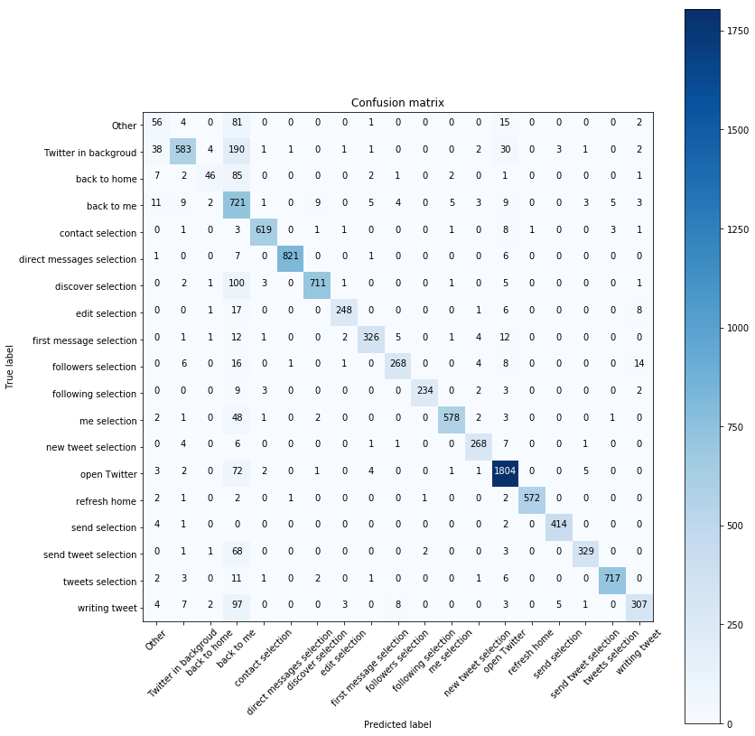

```python
# Convert predictions classes to one hot vectors
Y_pred_classes = np.argmax(Y_pred,axis = 1)
# Convert validation observations to one hot vectors
Y_true = np.argmax(Y_test,axis = 1)

Y_pred_name = []
Y_true_name = []

#Convert number to real value
for index in range(0, len(Y_pred_classes)):
    Y_pred_name.append(values[Y_pred_classes[index]])
    Y_true_name.append(values[Y_true[index]])


confusion_mtx = confusion_matrix(Y_true_name, Y_pred_name)

# plot the confusion matrix
plot_confusion_matrix(confusion_mtx, classes = values)
```

To increase the accuracy and the performance we perform a feature selection. Random Forest provide us the weigth related to each feature that has been computed. The features with a weigth less than 0.1 are removed.

```python
#Feature reduction according to the random forest weight
feature_imp = pd.Series(rf.feature_importances_).sort_values(ascending=False)
remove = []
print("Weighted features:")
for index in range(0,feature_imp.shape[0]):
    print(selected_features.columns[index],"has weight: %.4f " %feature_imp[index])
    if(feature_imp[index]<0.1):
        remove.append(selected_features.columns[index])

print("\nFeatures that will be removed:")
for index in range(0, len(remove)):
    print(remove[index])
```

```
Weighted features:
flow_length has weight: 0.0017
Num_flow has weight: 0.1876
Duration has weight: 0.2974
Avg_flow_length has weight: 0.2158
Mean_block has weight: 0.1588
Var_block has weight: 0.1012
Position has weight: 0.0018
Shift_from_start has weight: 0.0173
mean has weight: 0.0056
variance has weight: 0.0127

Features that will be removed:
flow_length
Position
Shift_from_start
mean
variance
```

```python
#Delete the less important feature, and train again the model
reduced_features = selected_features.drop(columns=remove)

print("Current Dataset after this stage:")
reduced_features
```

```
Current Dataset after this stage:
```

|  | Num_flow | Duration | Avg_flow_length | Mean_block | Var_block |
| --- | --- | --- | --- | --- | --- |
| 0 | 12 | 5.389641 | 6.750000 | 435.688575 | 307.327827 |
| 1 | 12 | 5.389641 | 6.750000 | 435.688575 | 307.327827 |
| 2 | 12 | 5.389641 | 6.750000 | 435.688575 | 307.327827 |
| 3 | 12 | 5.389641 | 6.750000 | 435.688575 | 307.327827 |
| 4 | 12 | 5.389641 | 6.750000 | 435.688575 | 307.327827 |
| 5 | 12 | 5.389641 | 6.750000 | 435.688575 | 307.327827 |
| 6 | 12 | 5.389641 | 6.750000 | 435.688575 | 307.327827 |
| 7 | 12 | 5.389641 | 6.750000 | 435.688575 | 307.327827 |
| 8 | 12 | 5.389641 | 6.750000 | 435.688575 | 307.327827 |
| 9 | 12 | 5.389641 | 6.750000 | 435.688575 | 307.327827 |
| 10 | 12 | 5.389641 | 6.750000 | 435.688575 | 307.327827 |
| 11 | 12 | 5.389641 | 6.750000 | 435.688575 | 307.327827 |
| 12 | 4 | 4.027171 | 1.000000 | 93.000000 | 0.000000 |
| 13 | 4 | 4.027171 | 1.000000 | 93.000000 | 0.000000 |
| 14 | 4 | 4.027171 | 1.000000 | 93.000000 | 0.000000 |
| 15 | 4 | 4.027171 | 1.000000 | 93.000000 | 0.000000 |
| 16 | 8 | 0.559473 | 7.250000 | 384.332347 | 226.966777 |
| 17 | 8 | 0.559473 | 7.250000 | 384.332347 | 226.966777 |
| 18 | 8 | 0.559473 | 7.250000 | 384.332347 | 226.966777 |
| 19 | 8 | 0.559473 | 7.250000 | 384.332347 | 226.966777 |
| 20 | 8 | 0.559473 | 7.250000 | 384.332347 | 226.966777 |
| 21 | 8 | 0.559473 | 7.250000 | 384.332347 | 226.966777 |
| 22 | 8 | 0.559473 | 7.250000 | 384.332347 | 226.966777 |
| 23 | 8 | 0.559473 | 7.250000 | 384.332347 | 226.966777 |
| 24 | 1 | 0.000000 | 1.000000 | 89.000000 | 0.000000 |
| 25 | 3 | 25.187670 | 1.000000 | 91.666667 | 0.000000 |
| 26 | 3 | 25.187670 | 1.000000 | 91.666667 | 0.000000 |
| 27 | 3 | 25.187670 | 1.000000 | 91.666667 | 0.000000 |
| 28 | 4 | 0.180141 | 3.250000 | 252.730363 | 145.286158 |
| 29 | 4 | 0.180141 | 3.250000 | 252.730363 | 145.286158 |
| ... | ... | ... | ... | ... | ... |
| 36229 | 3 | 12.429356 | 1.666667 | 114.650000 | 49.372335 |
| 36230 | 3 | 12.429356 | 1.666667 | 114.650000 | 49.372335 |
| 36231 | 3 | 12.429356 | 1.666667 | 114.650000 | 49.372335 |
| 36232 | 1 | 0.000000 | 1.000000 | 93.000000 | 0.000000 |
| 36233 | 4 | 56.275347 | 3.000000 | 238.310150 | 121.475107 |
| 36234 | 4 | 56.275347 | 3.000000 | 238.310150 | 121.475107 |
| 36235 | 4 | 56.275347 | 3.000000 | 238.310150 | 121.475107 |
| 36236 | 4 | 56.275347 | 3.000000 | 238.310150 | 121.475107 |
| 36237 | 1 | 0.000000 | 1.000000 | 93.000000 | 0.000000 |
| 36238 | 3 | 29.649355 | 4.000000 | 280.954011 | 173.203491 |
| 36239 | 3 | 29.649355 | 4.000000 | 280.954011 | 173.203491 |
| 36240 | 3 | 29.649355 | 4.000000 | 280.954011 | 173.203491 |
| 36241 | 1 | 0.000000 | 1.000000 | 93.000000 | 0.000000 |
| 36242 | 3 | 31.563147 | 3.666667 | 304.485902 | 189.982190 |
| 36243 | 3 | 31.563147 | 3.666667 | 304.485902 | 189.982190 |
| 36244 | 3 | 31.563147 | 3.666667 | 304.485902 | 189.982190 |
| 36245 | 4 | 5.732903 | 3.250000 | 245.778684 | 137.619372 |
| 36246 | 4 | 5.732903 | 3.250000 | 245.778684 | 137.619372 |
| 36247 | 4 | 5.732903 | 3.250000 | 245.778684 | 137.619372 |
| 36248 | 4 | 5.732903 | 3.250000 | 245.778684 | 137.619372 |
| 36249 | 1 | 0.000000 | 1.000000 | 93.000000 | 0.000000 |
| 36250 | 4 | 29.894217 | 3.250000 | 251.819913 | 133.584377 |
| 36251 | 4 | 29.894217 | 3.250000 | 251.819913 | 133.584377 |
| 36252 | 4 | 29.894217 | 3.250000 | 251.819913 | 133.584377 |
| 36253 | 4 | 29.894217 | 3.250000 | 251.819913 | 133.584377 |
| 36254 | 1 | 0.000000 | 1.000000 | 93.000000 | 0.000000 |
| 36255 | 3 | 31.421546 | 3.666667 | 272.103156 | 152.883815 |
| 36256 | 3 | 31.421546 | 3.666667 | 272.103156 | 152.883815 |
| 36257 | 3 | 31.421546 | 3.666667 | 272.103156 | 152.883815 |
| 36258 | 1 | 0.000000 | 1.000000 | 816.309469 | 458.651444 |

36259 rows × 5 columns

With the reduced dataset, we train another random forest. We plot at the end the number of misclassified samples, and the the performance.

```python
#Compute the previous operation

#Create the array with the dataframe
X=reduced_features.values.tolist() # Features
Y=one_hot.values.tolist()  # Labels

# Split dataset into training set and test set
X_train, X_test, Y_train, Y_test = train_test_split(X, Y, test_size=0.3)

rf2=RandomForestRegressor(n_estimators=1000, verbose = 0, max_depth = 30, n_jobs=-1)

#We evaluate the time
startTraining2 = time.time()
rf2.fit(X_train,Y_train)
endTraining2 = time.time()
print("TIME MEASUREMENT")
print("Total time for the new training: %.2f" %float(endTraining2 - startTraining2))
print("Previous total time for the training: %.2f" % float(endTraining - startTraining))

startTest2 = time.time()
Y_pred2=rf2.predict(X_test)
endTest2 = time.time()

print("Time occured for the new prediction %.2f" %float(endTest2-startTest2))
print("Previous time occured for the prediction %.2f" %float(endTest-startTest))
print("\nACCURACY MEASUREMENT")
#To calcualte accuracy I count the number of misclassified label
#The result will be a number of values equals to the number of a class
#The prediction is the index related to the highest value
#we define 2 other column for misclassification and accuracy
miss_for_label['Feat Red Misc']=0
miss_for_label['Feat Red Acc']=0


mis2 = 0
for index in range(0,Y_pred2.shape[0]):
    predicted_label = np.argmax(Y_pred2[index])
    real_label = np.argmax(Y_test[index])
    if(predicted_label != real_label):
        name_real = values[real_label]
        miss_for_label.loc[miss_for_label['Action'] == name_real, 'Feat Red Misc'] = miss_for_label.loc[miss_for_label['Action'] == name_real]['Feat Red Misc']+1
        mis2 += 1

miss_for_label['Feat Red Acc'] = 100-miss_for_label['Feat Red Misc']/miss_for_label['Number of sample']*100
print("Actual number of misclassified sample: ", mis2)
print("Previous misclassified sample: ",mis)
print("Total sample: ",Y_pred.shape[0] )
print("Previous Test Accuracy: %.2f" % (100-float(mis)/Y_pred.shape[0]*100))
print("Actual Test Accuracy: %.2f" % (100-float(mis2)/Y_pred.shape[0]*100))
print("New accuracy for each sample is:")
miss_for_label
```

```
TIME MEASUREMENT
Total time for the new training: 45.05
Previous total time for the training: 79.99
Time occured for the new prediction 1.23
Previous time occured for the prediction 1.08

ACCURACY MEASUREMENT
Actual number of misclassified sample:  1120
Previous misclassified sample:  1256
Total sample:  10878
Previous Test Accuracy: 88.45
Actual Test Accuracy: 89.70
New accuracy for each sample is:
```

|  | Action | Number of sample | Misclassification | Accuracy | Feat Red Misc | Feat Red Acc |
| --- | --- | --- | --- | --- | --- | --- |
| 0 | Other | 596 | 103 | 82.718121 | 117 | 80.369128 |
| 1 | Twitter in backgroud | 2951 | 274 | 90.715012 | 236 | 92.002711 |
| 2 | back to home | 507 | 101 | 80.078895 | 87 | 82.840237 |
| 3 | back to me | 2559 | 69 | 97.303634 | 46 | 98.202423 |
| 4 | contact selection | 2138 | 20 | 99.064546 | 27 | 98.737138 |
| 5 | direct messages selection | 2873 | 15 | 99.477898 | 10 | 99.651932 |
| 6 | discover selection | 2689 | 114 | 95.760506 | 96 | 96.429900 |
| 7 | edit selection | 917 | 33 | 96.401309 | 20 | 97.818975 |
| 8 | first message selection | 1154 | 39 | 96.620451 | 15 | 98.700173 |
| 9 | followers selection | 1009 | 50 | 95.044599 | 32 | 96.828543 |
| 10 | following selection | 929 | 19 | 97.954790 | 26 | 97.201292 |
| 11 | me selection | 2134 | 60 | 97.188379 | 55 | 97.422680 |
| 12 | new tweet selection | 1021 | 20 | 98.041136 | 15 | 98.530852 |
| 13 | open Twitter | 6278 | 91 | 98.550494 | 102 | 98.375279 |
| 14 | refresh home | 1992 | 9 | 99.548193 | 5 | 99.748996 |
| 15 | send selection | 1372 | 7 | 99.489796 | 10 | 99.271137 |
| 16 | send tweet selection | 1467 | 75 | 94.887526 | 100 | 93.183367 |
| 17 | tweets selection | 2221 | 27 | 98.784331 | 13 | 99.414678 |
| 18 | writing tweet | 1452 | 130 | 91.046832 | 108 | 92.561983 |

As in the previous case we print the confusion matrix.

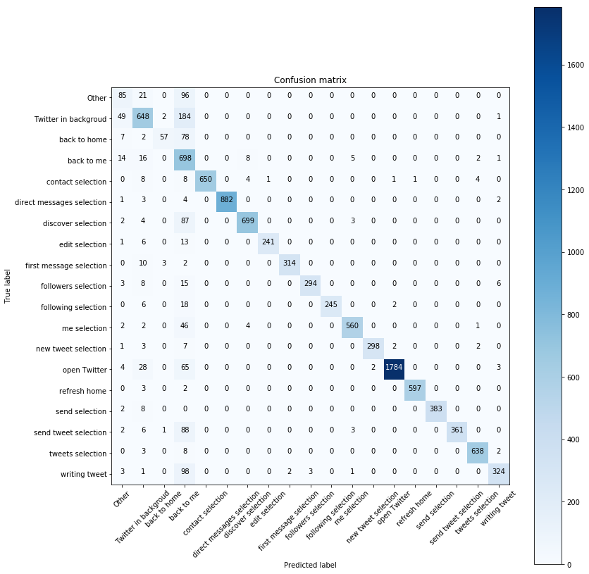

```python
#New confusion Matrix
# Convert predictions classes to one hot vectors
Y_pred_classes = np.argmax(Y_pred2,axis = 1)
# Convert validation observations to one hot vectors
Y_true = np.argmax(Y_test,axis = 1)

Y_pred_name = []
Y_true_name = []

#Convert number to real value
for index in range(0, len(Y_pred_classes)):
    Y_pred_name.append(values[Y_pred_classes[index]])
    Y_true_name.append(values[Y_true[index]])

confusion_mtx = confusion_matrix(Y_true_name, Y_pred_name)


# plot the confusion matrix
plot_confusion_matrix(confusion_mtx, classes = values)
```

# Neural Network

We obtain the best result with the usage of the Random Forest, but the first trial was with the usage of a neural network. For the sake of completeness we report also the result and the graph with neural network.

We consider the Neural network with all the inital features. The labels related to each flow are the same of the previous model. We need to define the list as numpy array for Input of Neural Network

```python
#Create the array with the dataframe
X=selected_features.values.tolist() # Features
Y=one_hot.values.tolist()  # Labels

# Split dataset into training set and test set
X_train, X_test, Y_train, Y_test = train_test_split(X, Y, test_size=0.3)
print("Size of train set: ",len(X_train))
print("Size of the test set: ",len(X_test))

X_train = np.array(X_train)
Y_train = np.array(Y_train)
X_test = np.array(X_test)
Y_test = np.array(Y_test)

#We need to define the number of classes. It will be the number of neuron at output layer
num_classes = len(values)
print("Number of classes: ",num_classes)
```

```
Size of train set:  25381
Size of the test set:  10878
Number of classes:  19
```

We define the model of our NN. We use as activation function the relu for all the hidden layers. Activation function for the output layer is the softmax. We use also a dropout function in order to prevent overfitting. The metrics used for the loss was categorical_crossentropy and we use the accuracy as a metrics for the compiling of the model.

```python
from sklearn.utils import shuffle
from keras import models
from keras import layers

def NN_model():
    model = models.Sequential()
    model.add(layers.Dense(512, activation = "relu", input_shape=(selected_features.shape[1],)))

    # Hidden - Layers
    model.add(layers.Dense(256, activation = "relu"))
    model.add(layers.Dropout(0.3, noise_shape=None, seed=None))
    model.add(layers.Dense(128, activation = "relu"))
    model.add(layers.Dropout(0.3, noise_shape=None, seed=None))
    model.add(layers.Dense(64, activation = "relu"))
    model.add(layers.Dropout(0.3, noise_shape=None, seed=None))
    model.add(layers.Dense(32, activation = "relu"))
    model.add(layers.Dropout(0.3, noise_shape=None, seed=None))

    # Output- Layer
    model.add(layers.Dense(num_classes, activation = "softmax"))

    model.compile(loss='categorical_crossentropy', optimizer='adam', metrics=['accuracy'])
    return model
```

We provide also a visualization of the neural network, with all the trainable parameters.

```python
model = NN_model()
model.summary()
```

```
_________________________________________________________________
Layer (type)                 Output Shape              Param #
=================================================================
dense_1 (Dense)              (None, 512)               5632
_________________________________________________________________
dense_2 (Dense)              (None, 256)               131328
_________________________________________________________________
dropout_1 (Dropout)          (None, 256)               0
_________________________________________________________________
dense_3 (Dense)              (None, 128)               32896
_________________________________________________________________
dropout_2 (Dropout)          (None, 128)               0
_________________________________________________________________
dense_4 (Dense)              (None, 64)                8256
_________________________________________________________________
dropout_3 (Dropout)          (None, 64)                0
_________________________________________________________________
dense_5 (Dense)              (None, 32)                2080
_________________________________________________________________
dropout_4 (Dropout)          (None, 32)                0
_________________________________________________________________
dense_6 (Dense)              (None, 19)                627
=================================================================
Total params: 180,819
Trainable params: 180,819
Non-trainable params: 0
_________________________________________________________________
```

Finally we train the network. We print the accuracy value and time necessary for training also for random forest for a better comparison.

```python
startTrainingNN1 = time.time()
history = model.fit(X_train, Y_train, epochs=500, batch_size=150)
endTrainingNN1 = time.time()
print("\nTIME MEASUREMENT")
print("Total time for the training on a NN: %.2f" %float(endTrainingNN1 - startTrainingNN1))
print("Total time for the training on a RF: %.2f" %float(endTraining2 - startTraining2))

startTestNN1 = time.time()
score = model.evaluate(X_test, Y_test, verbose=0)
endTestNN1 = time.time()

print("Time occured for the prediction on a NN %.2f" %float(endTestNN1-startTestNN1))
print("Time occured for the prediction on a RF %.2f" %float(endTest2-startTest2))

print("\nACCURACY MEASUREMENT")
print("Test accuracy on a NN: %.2f" % float(score[1]*100))
print("Test Accuracy on a RF: %.2f" % (100-float(mis2)/Y_pred.shape[0]*100))
```

```
TIME MEASUREMENT
Total time for the training on a NN: 1060.62
Total time for the training on a RF: 45.05
Time occured for the prediction on a NN 0.46
Time occured for the prediction on a RF 1.23

ACCURACY MEASUREMENT
Test accuracy on a NN: 72.85
Test Accuracy on a RF: 89.70
```

For a final visualization we print the accuracy at the loss at the different epoch. We provide also a confusion matrix for the neural network.

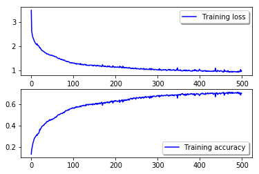

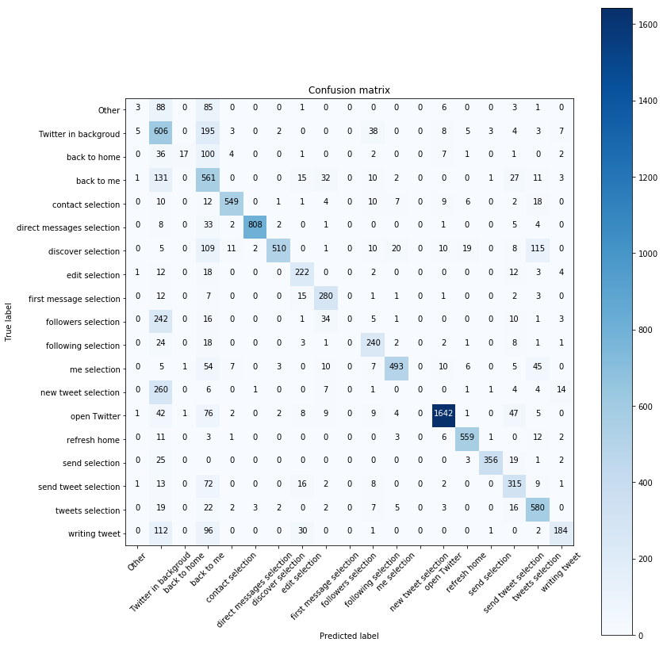

```python
fig,ax = plt.subplots(2,1)
#plt.figure(figsize=(7,7))
ax[0].plot(history.history['loss'], color='b', label="Training loss")
legend = ax[0].legend(loc='best', shadow=True)

ax[1].plot(history.history['acc'], color='b', label="Training accuracy")
legend = ax[1].legend(loc='best', shadow=True)


#Confusion Matrix
Y_pred_classes = np.argmax(Y_pred2,axis = 1)
# Convert validation observations to one hot vectors
Y_true = np.argmax(Y_test,axis = 1)

Y_pred_name = []
Y_true_name = []

Y_predNN = model.predict(X_test)
# Convert predictions classes to one hot vectors
Y_pred_classesNN = np.argmax(Y_predNN,axis = 1)
# Convert validation observations to one hot vectors
Y_trueNN = np.argmax(Y_test,axis = 1)

#Convert number to real value
for index in range(0, len(Y_pred_classes)):
    Y_pred_name.append(values[Y_pred_classesNN[index]])
    Y_true_name.append(values[Y_trueNN[index]])

confusion_mtx = confusion_matrix(Y_true_name, Y_pred_name)

# plot the confusion matrix
plot_confusion_matrix(confusion_mtx, classes = values)
```

We compute at the end the final table with the accuracy for each action for each estimator used.

```python
#define new columns
miss_for_label['NN Misc']=0
miss_for_label['NN Acc']=0


mis3 = 0
for index in range(0,Y_predNN.shape[0]):
    predicted_label = np.argmax(Y_predNN[index])
    real_label = np.argmax(Y_test[index])
    if(predicted_label != real_label):
        name_real = values[real_label]
        miss_for_label.loc[miss_for_label['Action'] == name_real, 'NN Misc'] = miss_for_label.loc[miss_for_label['Action'] == name_real]['NN Misc']+1
        mis3 += 1

miss_for_label['NN Acc'] = 100-miss_for_label['NN Misc']/miss_for_label['Number of sample']*100
print("Final Accuracy is the following")
miss_for_label
```

```
Final Accuracy is the following
```

|  | Action | Number of sample | Misclassification | Accuracy | Feat Red Misc | Feat Red Acc | NN Misc | NN Acc |
| --- | --- | --- | --- | --- | --- | --- | --- | --- |
| 0 | Other | 596 | 103 | 82.718121 | 117 | 80.369128 | 184 | 69.127517 |
| 1 | Twitter in backgroud | 2951 | 274 | 90.715012 | 236 | 92.002711 | 273 | 90.748899 |
| 2 | back to home | 507 | 101 | 80.078895 | 87 | 82.840237 | 154 | 69.625247 |
| 3 | back to me | 2559 | 69 | 97.303634 | 46 | 98.202423 | 233 | 90.894881 |
| 4 | contact selection | 2138 | 20 | 99.064546 | 27 | 98.737138 | 80 | 96.258185 |
| 5 | direct messages selection | 2873 | 15 | 99.477898 | 10 | 99.651932 | 56 | 98.050818 |
| 6 | discover selection | 2689 | 114 | 95.760506 | 96 | 96.429900 | 310 | 88.471551 |
| 7 | edit selection | 917 | 33 | 96.401309 | 20 | 97.818975 | 52 | 94.329335 |
| 8 | first message selection | 1154 | 39 | 96.620451 | 15 | 98.700173 | 42 | 96.360485 |
| 9 | followers selection | 1009 | 50 | 95.044599 | 32 | 96.828543 | 313 | 68.979187 |
| 10 | following selection | 929 | 19 | 97.954790 | 26 | 97.201292 | 61 | 93.433800 |
| 11 | me selection | 2134 | 60 | 97.188379 | 55 | 97.422680 | 153 | 92.830366 |
| 12 | new tweet selection | 1021 | 20 | 98.041136 | 15 | 98.530852 | 299 | 70.714985 |
| 13 | open Twitter | 6278 | 91 | 98.550494 | 102 | 98.375279 | 207 | 96.702772 |
| 14 | refresh home | 1992 | 9 | 99.548193 | 5 | 99.748996 | 39 | 98.042169 |
| 15 | send selection | 1372 | 7 | 99.489796 | 10 | 99.271137 | 50 | 96.355685 |
| 16 | send tweet selection | 1467 | 75 | 94.887526 | 100 | 93.183367 | 124 | 91.547376 |
| 17 | tweets selection | 2221 | 27 | 98.784331 | 13 | 99.414678 | 81 | 96.352994 |
| 18 | writing tweet | 1452 | 130 | 91.046832 | 108 | 92.561983 | 242 | 83.333333 |